# Homework #7

Natalia Aristizábal

10/17/2018

#### Creating Fake Data Sets To Explore Hypotheses

First, create any fake data, specify sample sizes, means, and variances.Then write a function to create random data set with those attributes organized into a data frame.

**Hypothesis**: Coffee yield will be greater in farms with higher forest cover.

**Data**: fruit size as proxy for coffee yield (pollination services), mapped farm property with percentages of forest cover, bee exclusion experiments in coffee flowers (presence or absence of bees).

**Indepedent variable**: amount of forest cover (continuous, real number)

**Dependent variable**: coffee berry weight in milligrams (continuous, real number)

#### Initial random data with normal distribution and under parameters as if my hypothesis were true

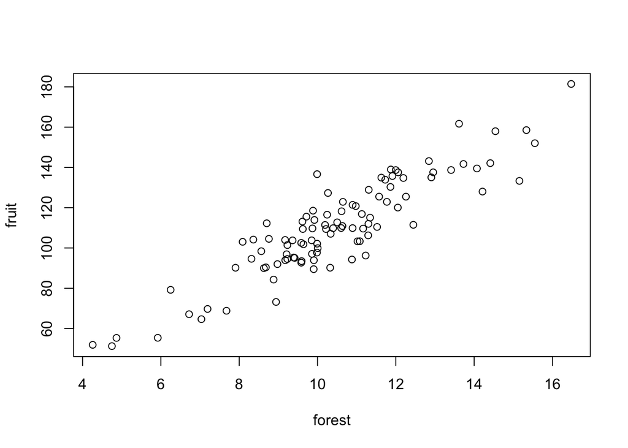

```r
library(ggplot2)

# Create random data
forest <- rnorm(n=100,mean=10,sd=2) # independent variable
noise <- rnorm(n=100, sd=10) # a noisy linear relationship with x
fruit <- 5.5 + forest*10 + noise # dependent variable

# with basic r
plot(forest,fruit)
```

```r
# organize data into a dataframe
ID <- seq_len(100)
regData <- data.frame(ID,forest,fruit)

# peak into the data frame to check
head(regData)
```

```
##   ID    forest     fruit
## 1  1 10.896099 121.41666
## 2  2  7.906096  90.19634
## 3  3  9.989586 136.66307
## 4  4 11.862610 130.32151
## 5  5  9.228434  94.52436
## 6  6 11.997292 138.69103
```

```r
str(regData)
```

```
## 'data.frame':    100 obs. of  3 variables:
##  $ ID    : int  1 2 3 4 5 6 7 8 9 10 ...
##  $ forest: num  10.9 7.91 9.99 11.86 9.23 ...
##  $ fruit : num  121.4 90.2 136.7 130.3 94.5 ...
```

#### Write simple code to analyze with a regression (fruit as function of forest) and visualize your data with ggplot2.

```r
# simple linear regression
regModel <- lm(fruit ~ forest, regData)

# regression's stats
summary(regModel)
```

```
##
## Call:
## lm(formula = fruit ~ forest, data = regData)
##
## Residuals:
##      Min       1Q   Median       3Q      Max
## -22.9114  -6.7265  -0.4071   7.2978  30.9129
##
## Coefficients:
##             Estimate Std. Error t value Pr(>|t|)
## (Intercept)   8.1105     4.9932   1.624    0.108
## forest        9.7741     0.4678  20.896   <2e-16 ***
## ---
## Signif. codes:  0 '***' 0.001 '**' 0.01 '*' 0.05 '.' 0.1 ' ' 1
##
## Residual standard error: 10.46 on 98 degrees of freedom
## Multiple R-squared:  0.8167, Adjusted R-squared:  0.8148
## F-statistic: 436.6 on 1 and 98 DF,  p-value: < 2.2e-16
```

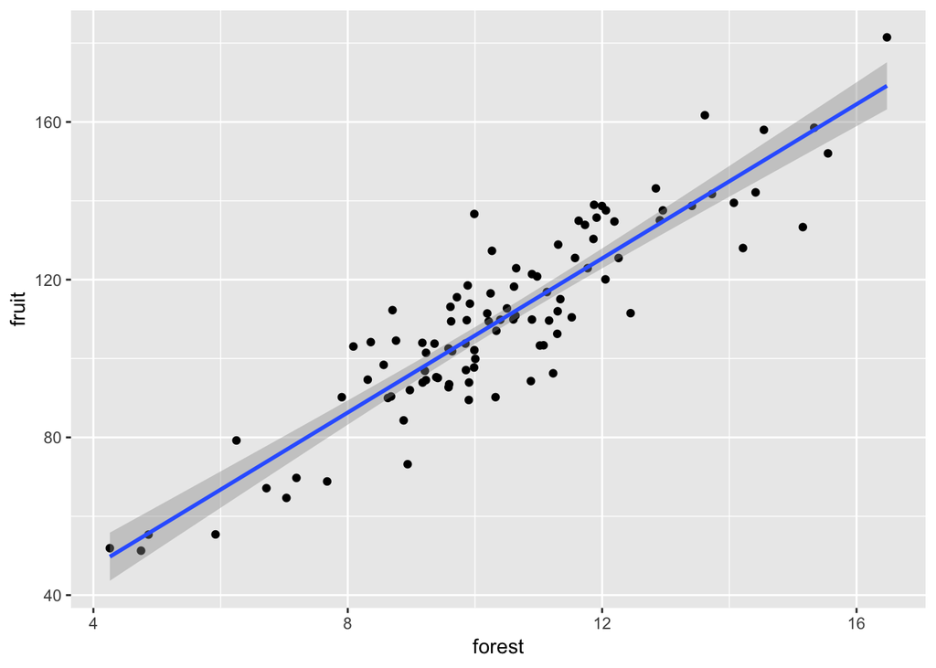

```r
# plot the data with ggplot2
regPlot <- ggplot(data=regData, aes(x=forest,y=fruit)) +
                 geom_jitter() +
                 stat_smooth(method=lm)

print(regPlot)
```

I ran the regression several times with different random set of numbers but with the same parameters and it always showed a significant positive relationship: The more forest cover, the bigger the coffee berries.

#### **Adjust the mean** of the data but keep all other parameters and sample size same as initial dataset. How small can the differences between the groups be (the “effect size”) for you to still detect a significant pattern (p < 0.05)?

```r
# change the mean
forest <- rnorm(n=100,mean=0.001,sd=2)
noise <- rnorm(n=100, sd=10)
fruit <- 5.5 + forest*10 + noise

# organize data into a dataframe
ID <- seq_len(100)
regData <- data.frame(ID,forest,fruit)

# peak into the data frame to check
head(regData)
```

```
##   ID     forest      fruit
## 1  1  2.5223904 36.1491474
## 2  2 -0.8465202 -9.2758518
## 3  3 -0.2766156  9.1060377
## 4  4  0.6747847 20.4118618
## 5  5  0.4654838  0.8546738
## 6  6 -0.1282567 15.8068414
```

```r
str(regData)
```

```
## 'data.frame':    100 obs. of  3 variables:
##  $ ID    : int  1 2 3 4 5 6 7 8 9 10 ...
##  $ forest: num  2.522 -0.847 -0.277 0.675 0.465 ...
##  $ fruit : num  36.149 -9.276 9.106 20.412 0.855 ...
```

```r
# simple linear regression
regModel <- lm(fruit ~ forest, regData)

# regression's stats
summary(regModel)
```

```
##
## Call:
## lm(formula = fruit ~ forest, data = regData)
##
## Residuals:
##     Min      1Q  Median      3Q     Max
## -36.767  -6.876   1.161   7.423  28.892
##
## Coefficients:
##             Estimate Std. Error t value Pr(>|t|)
## (Intercept)   7.2216     1.2302    5.87 5.94e-08 ***
## forest        8.6885     0.6085   14.28  < 2e-16 ***
## ---
## Signif. codes:  0 '***' 0.001 '**' 0.01 '*' 0.05 '.' 0.1 ' ' 1
##
## Residual standard error: 12.29 on 98 degrees of freedom
## Multiple R-squared:  0.6754, Adjusted R-squared:  0.6721
## F-statistic: 203.9 on 1 and 98 DF,  p-value: < 2.2e-16
```

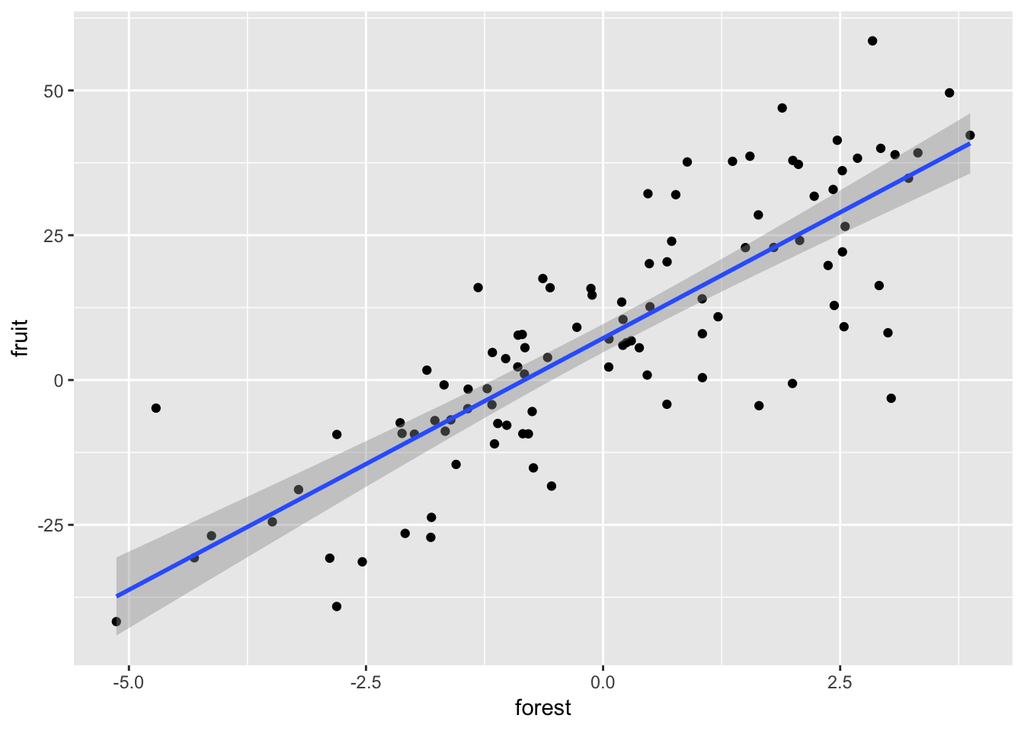

```r
# plot the data with ggplot2
regPlot <- ggplot(data=regData, aes(x=forest,y=fruit)) +
                 geom_jitter() +
                 stat_smooth(method=lm)

print(regPlot)
```

I reduced the mean gradually until mean=0.001 and increased until mean=99.9, and still got a p-value < 2.2^-16.

#### **Adjust the sample size** of the data but keep all other parameters same as initial dataset. What is the minimum sample size you would need in order to detect a statistically significant effect?

```r
# decrease sample size
forest <- rnorm(n=8,mean=10,sd=2)
noise <- rnorm(n=8, sd=10)
fruit <- 5.5 + forest*10 + noise

# organize data into a dataframe
ID <- seq_len(8)
regData <- data.frame(ID,forest,fruit)

# peak into the data frame to check
head(regData)
```

```
##   ID    forest     fruit
## 1  1  9.124184  79.07170
## 2  2  5.812079  72.82816
## 3  3 11.009537 119.38179
## 4  4  4.676178  32.52532
## 5  5  9.707886  89.60330
## 6  6 14.727982 142.60102
```

```r
str(regData)
```

```
## 'data.frame':    8 obs. of  3 variables:
##  $ ID    : int  1 2 3 4 5 6 7 8
##  $ forest: num  9.12 5.81 11.01 4.68 9.71 ...
##  $ fruit : num  79.1 72.8 119.4 32.5 89.6 ...
```

```r
# simple linear regression
regModel <- lm(fruit ~ forest, regData)

# regression's stats
summary(regModel)
```

```
##
## Call:
## lm(formula = fruit ~ forest, data = regData)
##
## Residuals:
##     Min      1Q  Median      3Q     Max
## -11.094  -5.861  -2.111   2.712  17.767
##
## Coefficients:
##             Estimate Std. Error t value Pr(>|t|)
## (Intercept)   -3.480     12.328  -0.282 0.787184
## forest        10.072      1.314   7.665 0.000258 ***
## ---
## Signif. codes:  0 '***' 0.001 '**' 0.01 '*' 0.05 '.' 0.1 ' ' 1
##
## Residual standard error: 10.81 on 6 degrees of freedom
## Multiple R-squared:  0.9073, Adjusted R-squared:  0.8919
## F-statistic: 58.75 on 1 and 6 DF,  p-value: 0.0002578
```

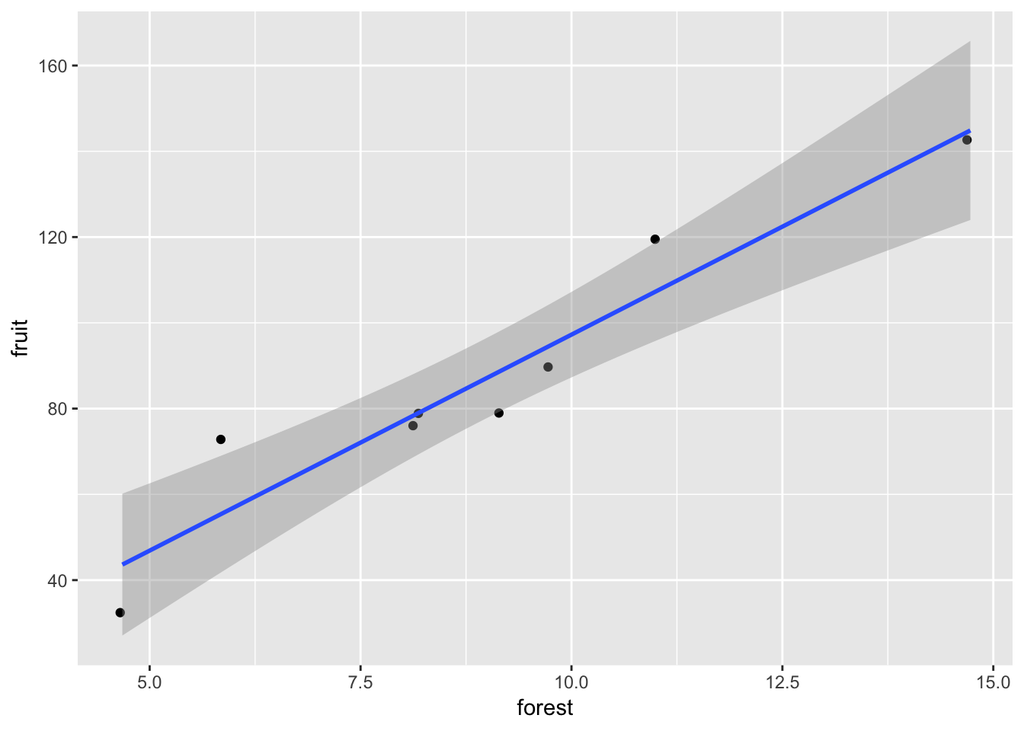

```r
# plot the data with ggplot2
regPlot <- ggplot(data=regData, aes(x=forest,y=fruit)) +
                 geom_jitter() +
                 stat_smooth(method=lm)

print(regPlot)
```

With a sample size of 3, 4, and 5 ocassionally you find a significant relationship, but more often you don’t. When the sample size is 6 or 7, most times you will find a p-value <0.05, but ocassionally you will not. I ran the model dozens of times with a sample size of 8 and every time it returned a p-value < 0.05. I guess the minimum sample size I is 8.

#### **Adjust the variance** of the data but keep all other parameters and sample size same as initial dataset. How does the variance influence the detection of a statistically significant result?

```r
# change variance
forest <- rnorm(n=100,mean=10,sd=0.4)
noise <- rnorm(n=100, sd=10)
fruit <- 5.5 + forest*10 + noise

# organize data into a dataframe
ID <- seq_len(100)
regData <- data.frame(ID,forest,fruit)

# peak into the data frame to check
head(regData)
```

```
##   ID    forest     fruit
## 1  1  9.909651 113.45609
## 2  2  9.656144 118.34717
## 3  3  9.830219 109.43278
## 4  4 10.259969  95.82705
## 5  5  9.890876 107.55647
## 6  6 10.170922 116.27734
```

```r
str(regData)
```

```
## 'data.frame':    100 obs. of  3 variables:
##  $ ID    : int  1 2 3 4 5 6 7 8 9 10 ...
##  $ forest: num  9.91 9.66 9.83 10.26 9.89 ...
##  $ fruit : num  113.5 118.3 109.4 95.8 107.6 ...
```

```r
# simple linear regression
regModel <- lm(fruit ~ forest, regData)

# regression's stats
summary(regModel)
```

```
##
## Call:
## lm(formula = fruit ~ forest, data = regData)
##
## Residuals:
##      Min       1Q   Median       3Q      Max
## -23.8933  -7.6030   0.1242   8.0498  22.2030
##
## Coefficients:
##             Estimate Std. Error t value Pr(>|t|)
## (Intercept)  -12.836     27.225  -0.471    0.638
## forest        11.812      2.726   4.334 3.55e-05 ***
## ---
## Signif. codes:  0 '***' 0.001 '**' 0.01 '*' 0.05 '.' 0.1 ' ' 1
##
## Residual standard error: 10.26 on 98 degrees of freedom
## Multiple R-squared:  0.1608, Adjusted R-squared:  0.1523
## F-statistic: 18.78 on 1 and 98 DF,  p-value: 3.553e-05
```

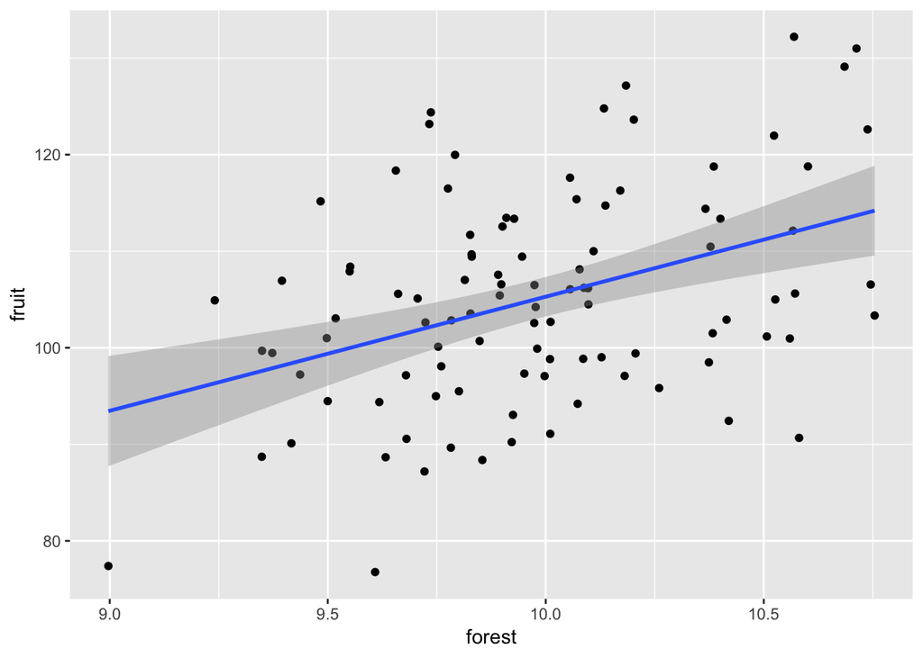

```r
# plot the data with ggplot2
regPlot <- ggplot(data=regData, aes(x=forest,y=fruit)) +
                 geom_jitter() +
                 stat_smooth(method=lm)

print(regPlot)
```

- The variance could increase all the way to sd=500 and it returned the same p-value.
- Decreasing sd=0.1 makes the p-value fluctuate, sometimes less than 0.05 and sometimes more.
- At sd= 0.4 it will still return a significant p-value, but at sd=03 it fluctuates between significant and not.